# Lab 6: Machine Learning II

In this lab we will first continue with breast cancer biopsy data from the University of Wisconsin. This dataset is available as `brca` in the `dslabs` package and is also part of the UCI Machine Learning Repository. `brca` is a binary classification dataset for 569 malignant (cancer) and benign (not cancer) breast masses. 30 continuous features were computationally extracted from digital images of fine needle aspirate biopsy slides.

For simplicity, let’s focus on only the first two predictors, `radius_mean` and `texture_mean`. In the code chunk below, we construct a data frame called `data` with four variables:

- `labels`: a factor with two levels denoting whether a mass is “Benign” or “Malignant”. This will be useful for summarizing and plotting the data.
- `y`: a numeric vector that encodes the outcomes as 0 for Benign and 1 for Malignant. This will be useful for model fitting.
- `radius_mean`: the mean nucleus radius
- `texture_mean`: the mean nucleus texture

```r
library(tidyverse)
library(caret)
library(dslabs)
library(splitstackshape)
data(brca)

data = data.frame(labels = factor(ifelse(brca$y == "B", "Benign", "Malignant")),
                  y = factor(ifelse(brca$y == "B", 0, 1)),
                  radius_mean = brca$x[,"radius_mean"],
                  texture_mean = brca$x[,"texture_mean"])
```

Run the code below to create training and test sets. We will use a 70% training, 30% test set split. Note that we have an imbalance in outcome groups (212/569 = 37% of masses are malignant and 63% are not), so we need to take this into account when we split our data into training and test sets. Here we use the function `stratified` from the `splitstackshape` package to split the data. The stratified function samples the same percent of individuals from each class - in this case, `y`. Finally, `set.seed(219)` ensures reproducibility, so that we get the same random split every time we run the code.

```r
set.seed(219)

x           <- stratified(data, "y", 0.7, keep.rownames = TRUE)
train_set   <- x %>% dplyr::select(-rn) # Remove row numbers
train_index <- as.numeric(x$rn)
test_set    <- data[-train_index,]
test_set_y  <- as.factor(test_set$y)

head(train_set)
```

```
##    labels      y radius_mean texture_mean
##    <fctr> <fctr>       <num>        <num>
## 1: Benign      0       12.80        17.46
## 2: Benign      0       12.34        14.95
## 3: Benign      0       11.27        15.50
## 4: Benign      0       13.28        13.72
## 5: Benign      0       13.64        15.60
## 6: Benign      0       10.08        15.11
```

```r
head(test_set)
```

```
##    labels y radius_mean texture_mean
## 4  Benign 0      13.030        18.42
## 11 Benign 0      11.520        18.75
## 12 Benign 0      13.050        19.31
## 13 Benign 0       8.618        11.79
## 14 Benign 0      10.170        14.88
## 20 Benign 0      12.780        16.49
```

## 1. k-Nearest Neighbors (KNN) for binary classification

### Question 1.1

Using 5-fold cross-validation, train a KNN model that predicts `y` based on `radius_mean` and `texture_mean`. Use `metric = "ROC"`. Then, use the `predict` function to get predicted probabilities for the test set, and convert the probabilities to predicted response labels (use a cutoff of 0.5). Be sure to standardize (preprocess) your data in the `train` function, and use values k = 3, 5, 7, …, 31 for the `tuneGrid` argument.

```r
# Your code here
```

### Question 1.2

Obtain the confusion matrix for the test set. Compare the performance of your KNN model with the Naive Bayes and logistic regression models from lab 5.

```r
# Your code here
```

## 2. Regression and Decision Trees for Continuous Outcomes

In this part of the lab, we will predict infant birth weight in grams using the `birthwt` dataset, available in the `MASS` package. This dataset of 189 observations was collected at the Baystate Medical Center in Springfield, MA during 1986. It includes the following variables:

- `low`: indicator of birth weight less than 2.5 kg (0 = more than 2.5 kg, 1 = less than 2.5 kg).
- `age`: mother’s age in years.
- `lwt`: mother’s weight in pounds at last menstrual period.
- `race`: mother’s race (1 = white, 2 = black, 3 = other).
- `smoke`: smoking status during pregnancy (0 = nonsmoker, 1 = smoker).
- `ptl`: number of previous premature labors.
- `ht`: history of hypertension (0 = no history, 1 = history of hypertension).
- `ui`: presence of uterine irritability (0 = no presence, 1 = presence of uterine irritability).
- `ftv`: number of physician visits during the first trimester.
- `bwt`: birth weight in grams.

```r
library(tidyverse)
library(caret)
library(rpart)
library(MASS)

data(birthwt)
```

Since we are interested in predicting birth weight, we drop the `low` indicator from the dataset. We also convert `race`, `smoke`, `ht`, and `ui` to factors, because these variables are categorical and not numeric/continuous.

Comment: Both the `dplyr` and `MASS` packages export a function called `select`, which is why the `dplyr::` is necessary in `dplyr::select`. This makes it clear to R that we want to use the `select` function from the `dplyr` package.

```r
birthwt <-
  birthwt %>%
  dplyr::select(-low) %>%
  mutate(race = factor(race),
         smoke = factor(smoke),
         ht = factor(ht),
         ui = factor(ui))
```

We use `createDataPartition` to split the birth weight data into training and test sets with 70% of the data in the training set and 30% in the test set.

```r
set.seed(9)

# Create an index for training rows using caret
train_index <- createDataPartition(y = birthwt$bwt, p = 0.7, list = FALSE)

birthwt_train_set <- birthwt[train_index, ]
birthwt_test_set  <- birthwt[-train_index, ]

nrow(birthwt_train_set)
```

```
## [1] 134
```

```r
nrow(birthwt_test_set)
```

```
## [1] 55
```

### Question 2.1

Based on the training set, make some plots to help you assess the relationship between our outcome of interest, `bwt`, and each of the other eight variables in the dataset. Which variables seem like good predictors of birth weight?

```r
# Your code here
```

### Question 2.2

Fit a regression tree that predicts `bwt` using all of the other variables in the training data. You can use the `tree` function from the `tree` package. Make a plot that visualizes the tree.

```r
# Your code here
```

### Question 2.3

For the model from Q2.2, calculate birth weight predictions for the observations in the test set. Calculate the RMSE and interpret it.

```r
# Your code here
```

## 3. Decision Trees, Bagging, and Random Forests for Multi-Class Outcomes

In the final section of this lab, we will use gene expression data to classify tissue samples. The data can be loaded from the `dslabs` package by calling `data(tissue_gene_expression)`. `tissuesGeneExpression` is a list with two elements:

- `x`: Numeric matrix with 189 rows and 500 columns. Each column contains gene expression measurements for a different gene.
- `y`: Factor vector of length 189 that records tissue type labels (cerebellum, colon, endometrium, hippocampus, kidney, liver, or placenta) .

The original data (accessible in the `tissuesGeneExpression` package) records gene expression for 22,215 genes.

```r
library(tidyverse)
library(caret)
library(GGally)
library(tree)
library(randomForest)
library(dslabs)

data(tissue_gene_expression)
```

We will only use a random sample of 100 genes to predict tissue type.

```r
set.seed(25)
tiss_ge <-
  data.frame(y = tissue_gene_expression$y,
             tissue_gene_expression$x[,sample(500, 100)])
```

As usual, we split the data into training and test sets, with 70% in the training set and 30% in the test set.

```r
set.seed(36)
tiss_ge_index_train <- createDataPartition(y = tiss_ge$y,
                                           times = 1, p = 0.7, list = FALSE)

tiss_ge_train_set <- tiss_ge[tiss_ge_index_train, ]
tiss_ge_test_set  <- tiss_ge[-tiss_ge_index_train, ]

nrow(tiss_ge_train_set)
```

```
## [1] 136
```

```r
nrow(tiss_ge_test_set)
```

```
## [1] 53
```

### Question 3.1

Below, you will find some plots and tables of the training set designed to help you develop some intuition for the data. Describe what you see.

This is a frequency table for the tissue types in the training data.

```r
table(tiss_ge_train_set$y)
```

```
##
##  cerebellum       colon endometrium hippocampus      kidney       liver
##          27          24          11          22          28          19
##    placenta
##           5
```

It is difficult to make visualizations for all 100 genes in the dataset, so let’s randomly sample six to focus on.

```r
set.seed(49)
genes6 <- sample(names(tiss_ge)[-1], 6)
genes6
```

```
## [1] "CAMK1G" "COPB1"  "LGALSL" "RPE65"  "GNA11"  "MYL7"
```

Here are histograms of the gene expression distributions of the six genes.

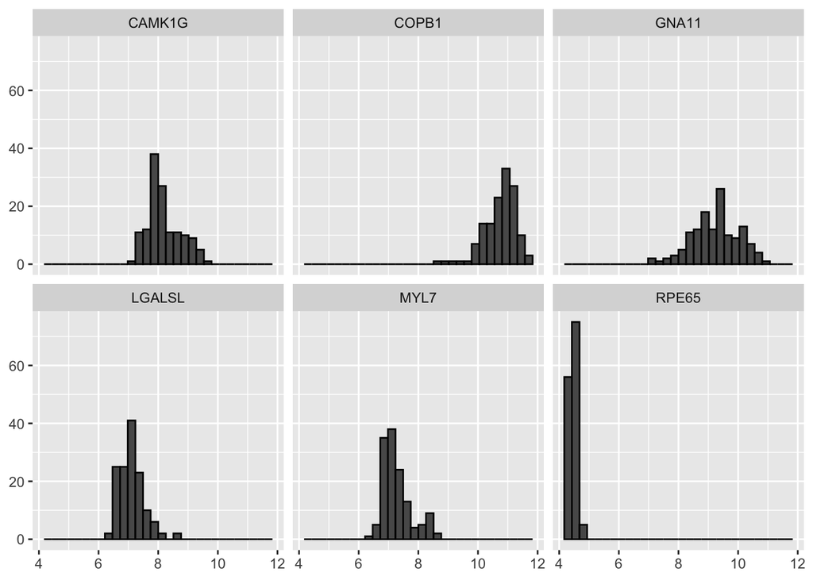

```r
tiss_ge_train_set %>%
  pivot_longer(cols = genes6,
               values_to = 'expression',
               names_to = 'gene') %>%
  ggplot(aes(x = expression)) +
  geom_histogram(color = "black") +
  facet_wrap(~gene) +
  xlab(NULL) + ylab(NULL)
```

The boxplots below plot gene expression against tissue type for the six genes. Note that setting `scales = 'free_y'` allows the y-axis to vary from plot to plot, so they are not on the same scale.

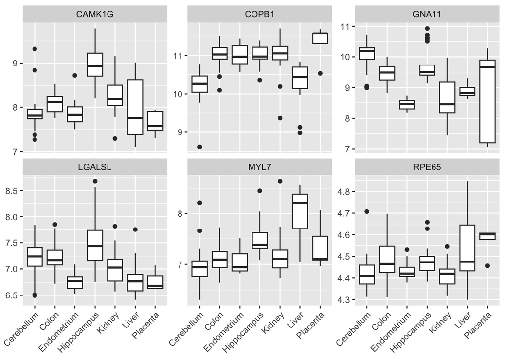

```r
tiss_ge_train_set %>%
  pivot_longer(cols = genes6,
               values_to = 'expression',
               names_to = 'gene') %>%
  ggplot(aes(x = y, y = expression)) +
  geom_boxplot() +
  facet_wrap(~ gene, scales = 'free_y') +
  xlab(NULL) + ylab(NULL) +
  scale_x_discrete(labels = str_to_title(unique(tiss_ge_train_set$y))) +
  theme(axis.text.x = element_text(angle = 45, hjust=1))
```

The `ggcorr` function from the `GGally` package makes pretty correlation matrix plots. Each tiny square in this plot represents the correlation between a pair of genes (out of the entire set of 100 genes). Red indicates positive correlation (close to 1), blue indicates negative correlation (close to -1), and white indicates no correlation (close to 0).

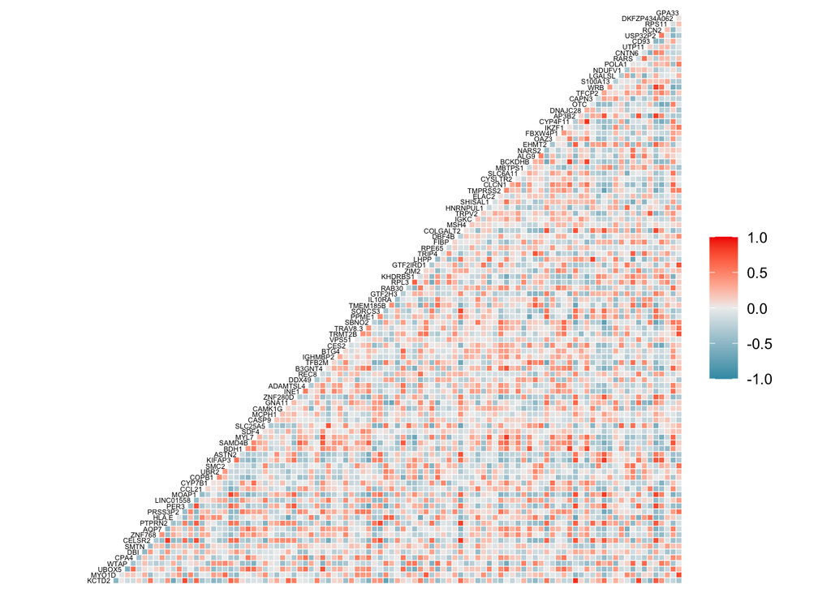

```r
ggcorr(tiss_ge_train_set[,-1], hjust = 1, size = 1.5, layout.exp = 10)
```

### Question 3.2

Fit a bagging (bootstrap aggregation) model to the training data by running `randomForest` from the `randomForest` package with the `mtry` parameter set to the number of predictors (`mtry = 100`). Be sure to set a random seed so that your code is reproducible (the solutions use `set.seed(64)`). Get the predicted class labels for the test set data and report the test accuracy.

```r
# Your code here
```

### Question 3.3

Now, build a random forest model with the `mtry` parameter set to the square root of the number of predictors. Also, set `importance = TRUE` so that the importance of the predictors is assessed. You will need the variable importance information for Q3.4. Be sure to set a random seed so that your code is reproducible (the solutions use `set.seed(81)`). Get the predicted class labels for the test set data and report the test accuracy.

```r
# Your code here
```

### Question 3.4

Run the `importance` function on your random forest model from Q3.3 to extract variable importance measures for each of the tissue types. Find the five most important genes for classifying kidney tissues by ordering the Gini index measures.

```r
# Your code here
```